# Boxplots, Violin Plots, And Outliers

# Goal

This notebook shows how to use summaries, boxplots, violin plots, and tables to understand spread and unusual values. We’ll continue with the NHANES teaching file.

# Analytic Questions

- How much spread is there?
- How do boxplots connect to IQR fences?
- What do violin plots show that boxplots hide?
- Which values might deserve follow-up by a simple IQR rule?

# Load Data

```r
nhanes <- readr::read_csv("data/real/nhanes_2021_2023_analysis.csv")
nhanes |>
  glimpse()
```

```
Rows: 11,933
Columns: 57
$ respondent_id                 <dbl> 130378, 130379, 130380, 130381, 130382, …
$ release_cycle                 <dbl> 12, 12, 12, 12, 12, 12, 12, 12, 12, 12, …
$ interview_exam_status         <chr> "interviewed_and_examined", "interviewed…
$ gender                        <chr> "male", "male", "female", "female", "mal…
$ age_years                     <dbl> 43, 66, 44, 5, 2, 3, 43, 65, 34, 68, 27,…
$ age_months_screening_0_to_24  <dbl> NA, NA, NA, NA, NA, NA, NA, NA, NA, NA, …
$ age_group                     <chr> "30-44", "65-79", "30-44", "0-17", "0-17…
$ race_ethnicity                <chr> "Non-Hispanic Asian", "Non-Hispanic Whit…
$ exam_period                   <chr> "May-October", "May-October", "November-…
$ born_in_us                    <chr> "no", "yes", "no", "yes", "yes", "yes", …
$ years_in_us_category          <chr> "20 years or more", NA, "20 years or mor…
$ education_adults_20_plus      <chr> "College graduate or above", "College gr…
$ marital_status_adults_20_plus <chr> "Married/living with partner", "Married/…
```

[output cut: 44 more lines]

# Prepare Dietary Data

| Data preparation step | Functions in this chunk |
| --- | --- |
| Keep or remove rows | `filter()` |
| Choose or rename columns | `select()` |

```r
diet <- nhanes |>
  filter(!is.na(mean_daily_energy_kcal))

diet |>
  select(respondent_id, age_years, gender, age_group, mean_daily_energy_kcal) |>
  head()
```

```
# A tibble: 6 × 5
  respondent_id age_years gender age_group mean_daily_energy_kcal
          <dbl>     <dbl> <chr>  <chr>                      <dbl>
1        130378        43 male   30-44                      1390
2        130379        66 male   65-79                      2484.
3        130380        44 female 30-44                      1735
4        130381         5 female 0-17                       1372
5        130382         2 male   0-17                       1144.
6        130386        34 male   30-44                      2133
```

The dietary summaries are simple averages over available recall days. They are for exploratory teaching examples, not formal usual-intake estimation.

# Summarize Spread

Summaries can describe spread in a few numbers.

| Data preparation step | Functions in this chunk |
| --- | --- |
| Count or summarize | `summarize()`; `n()` |

```r
energy_summary <- diet |>
  summarize(
    n = n(),
    mean_energy = mean(mean_daily_energy_kcal),
    median_energy = median(mean_daily_energy_kcal),
    min_energy = min(mean_daily_energy_kcal),
    max_energy = max(mean_daily_energy_kcal),
    iqr_energy = IQR(mean_daily_energy_kcal),
    sd_energy = sd(mean_daily_energy_kcal)
  )

energy_summary
```

```
# A tibble: 1 × 7
      n mean_energy median_energy min_energy max_energy iqr_energy sd_energy
  <int>       <dbl>         <dbl>      <dbl>      <dbl>      <dbl>     <dbl>
1  6752       1915.          1817          0      10446       938.      806.
```

The range shows the full span. The IQR describes the middle 50% of values. The standard deviation describes spread around the mean.

These summaries are useful, but they do not show the shape of the tails. That is why we plot too.

# Screen For Unusual Values

Here, we’ll calculate quartiles and IQR fences ourself. `ggplot2` will do this for us, but it’s always useful to remember how these work.

| Data preparation step | Functions in this chunk |
| --- | --- |
| Count or summarize | `summarize()` |

```r
energy_cutoffs <- diet |>
  summarize(
    q1 = quantile(mean_daily_energy_kcal, 0.25),
    q3 = quantile(mean_daily_energy_kcal, 0.75),
    iqr = IQR(mean_daily_energy_kcal),
    lower_cutoff = q1 - 1.5 * iqr,
    upper_cutoff = q3 + 1.5 * iqr
  )

energy_cutoffs
```

```
# A tibble: 1 × 5
     q1    q3   iqr lower_cutoff upper_cutoff
  <dbl> <dbl> <dbl>        <dbl>        <dbl>
1 1389. 2327.  938.        -18.9        3735.
```

We calculate two fences/cutoffs. For this question, we’ll focus on the high end of values, so we flag only values above the upper cutoff.

| Data preparation step | Functions in this chunk |
| --- | --- |
| Create or change columns | `mutate()` |
| Count or summarize | `count()` |

```r
diet_flagged <- diet |>
  mutate(
    high_energy_outlier = mean_daily_energy_kcal > energy_cutoffs$upper_cutoff
  )

diet_flagged |>
  count(high_energy_outlier)
```

```
# A tibble: 2 × 2
  high_energy_outlier     n
  <lgl>               <int>
1 FALSE                6593
2 TRUE                  159
```

| Data preparation step | Functions in this chunk |
| --- | --- |
| Keep or remove rows | `filter()` |

```r
diet_not_flagged <- diet_flagged |>
  filter(!high_energy_outlier)

diet_high_flagged <- diet_flagged |>
  filter(high_energy_outlier)
```

These are the same basic fences that `ggplot2` uses by default when it draws a boxplot. The default boxplot rule is:

- lower fence: Q1 - 1.5 x IQR
- upper fence: Q3 + 1.5 x IQR

Points beyond those fences are drawn as outlier points.

# Inspect Flagged Rows

Flagged values are not automatically errors. Often they’re perfectly natural results of the natural/social world.

| Data preparation step | Functions in this chunk |
| --- | --- |
| Keep or remove rows | `filter()` |
| Choose or rename columns | `select()` |
| Sort rows | `arrange()`; `desc()` |

```r
diet_flagged |>
  filter(high_energy_outlier) |>
  select(respondent_id, age_years, gender, age_group, dietary_days, mean_daily_energy_kcal) |>
  arrange(desc(mean_daily_energy_kcal)) |>
  head(10)
```

```
# A tibble: 10 × 6
   respondent_id age_years gender age_group dietary_days mean_daily_energy_kcal
           <dbl>     <dbl> <chr>  <chr>            <dbl>                  <dbl>
 1        139174        27 male   18-29                1                 10446
 2        135541        68 male   65-79                1                  8179
 3        135173        58 male   45-64                2                  8135
 4        138180        18 male   18-29                1                  7645
 5        136473        60 male   45-64                2                  6977
 6        130904        28 male   18-29                1                  6723
 7        139856        35 male   30-44                1                  6657
 8        131077        47 male   45-64                2                  6650.
 9        130801        56 male   45-64                2                  6502.
10        131498        41 female 30-44                2                  6306.
```

## Compare Groups With A Box Plot

`ggplot2` makes it very easy to create boxplots.

The box shows the middle 50% of the data. The line inside the box is the median. The points beyond the whiskers use the same 1.5 IQR idea we calculated above.

Start with a one-variable boxplot. There is no grouping variable here, so every participant is part of the same distribution.

| Plot component | Code in this chunk |
| --- | --- |
| Aesthetic mappings | `y` |
| Geoms / stats | `geom_boxplot()` |
| Scales / coordinates / facets / labels | `labs()`; `theme_minimal()` |

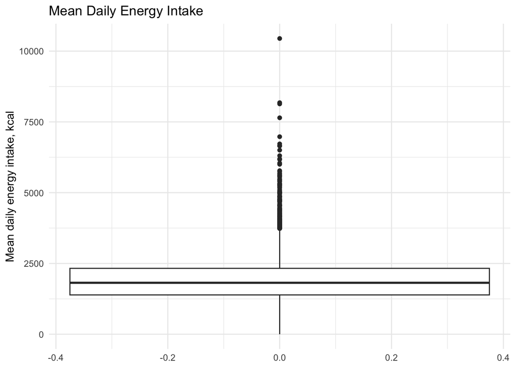

```r
ggplot(
  diet,
  aes(y = mean_daily_energy_kcal)
) +
  geom_boxplot() +
  labs(
    title = "Mean Daily Energy Intake",
    x = NULL,
    y = "Mean daily energy intake, kcal"
  ) +
  theme_minimal()
```

Now draw the 1.5 IQR upper fence that we calculated earlier. Everything above the red line is beyond the 1.5 IQR upper fence.

| Plot component | Code in this chunk |
| --- | --- |
| Geoms / stats | `geom_boxplot()`; `geom_hline()` |
| `geom_hline()` properties | `color`; `linewidth` |

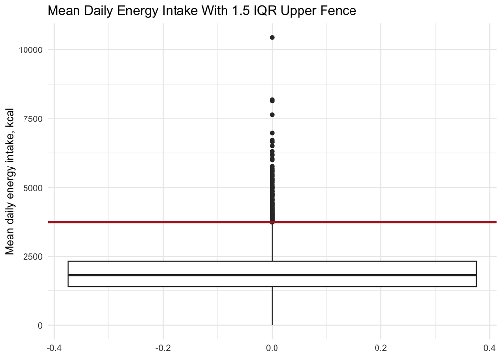

```r
ggplot(
  diet,
  aes(y = mean_daily_energy_kcal)
) +
  geom_boxplot() +
  geom_hline(
    yintercept = energy_cutoffs$upper_cutoff,
    color = "firebrick",
    linewidth = 1
  ) +
  labs(
    title = "Mean Daily Energy Intake With 1.5 IQR Upper Fence",
    x = NULL,
    y = "Mean daily energy intake, kcal"
  ) +
  theme_minimal()
```

The line makes the math visible: `geom_boxplot()` is using the same kind of fence we calculated by hand.

We can also make grouped boxplots.

| Plot component | Code in this chunk |
| --- | --- |
| Aesthetic mappings | `x`; `y` |
| Geoms / stats | `geom_boxplot()` |

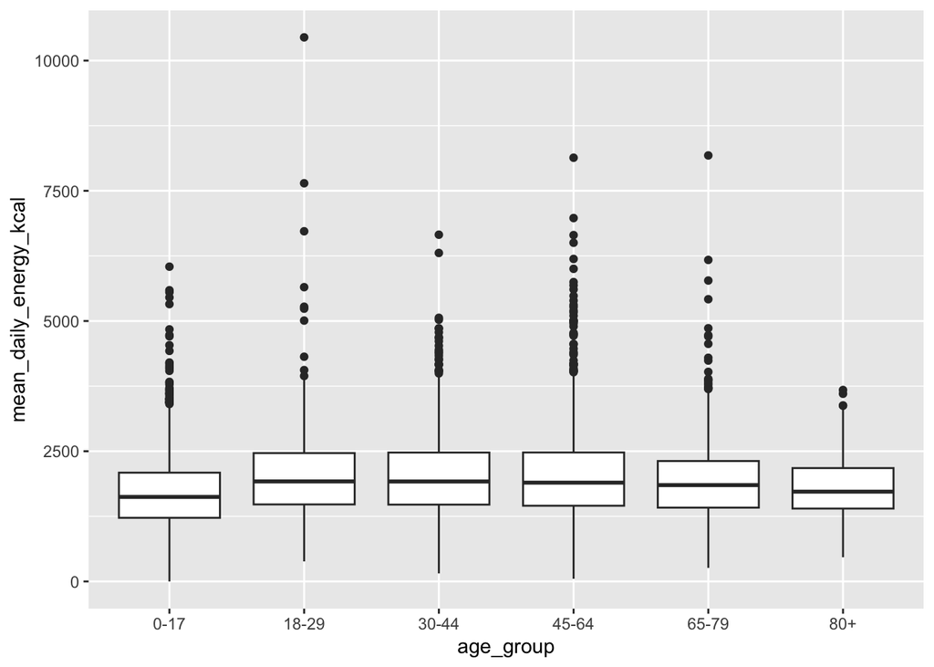

```r
p1 <- ggplot(
  diet,
  aes(x = age_group, y = mean_daily_energy_kcal)
) +
  geom_boxplot()

p1
```

| Plot component | Code in this chunk |
| --- | --- |
| Scales / coordinates / facets / labels | `labs()`; `theme_minimal()` |

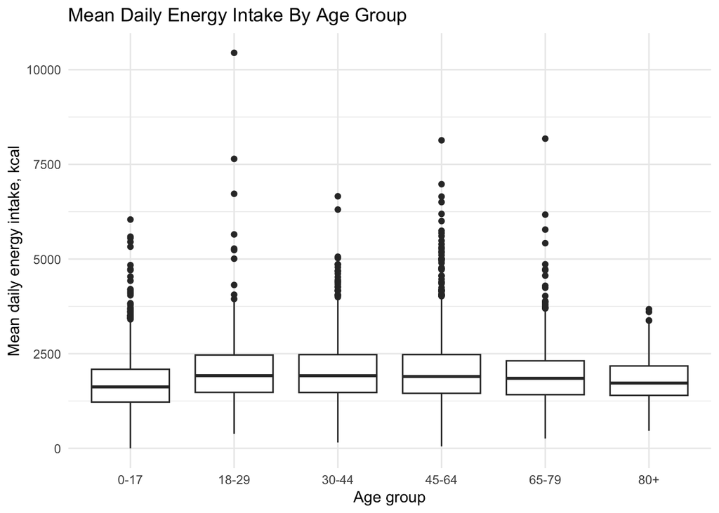

```r
p2 <- p1 +
  labs(
    title = "Mean Daily Energy Intake By Age Group",
    x = "Age group",
    y = "Mean daily energy intake, kcal"
  ) +
  theme_minimal()

p2
```

## Change The Boxplot Rule

The default `coef` is `1.5`, which means the whiskers extend to values within 1.5 IQRs of the box.

We can change that. A larger `coef` makes fewer points appear as outliers because the whiskers can extend farther.

First, calculate the 3.0 IQR fences from the same quartiles and IQR.

| Data preparation step | Functions in this chunk |
| --- | --- |
| Count or summarize | `summarize()` |

```r
energy_cutoffs_3 <- diet |>
  summarize(
    q1 = quantile(mean_daily_energy_kcal, 0.25),
    q3 = quantile(mean_daily_energy_kcal, 0.75),
    iqr = IQR(mean_daily_energy_kcal),
    lower_cutoff = q1 - 3 * iqr,
    upper_cutoff = q3 + 3 * iqr
  )

energy_cutoffs_3
```

```
# A tibble: 1 × 5
     q1    q3   iqr lower_cutoff upper_cutoff
  <dbl> <dbl> <dbl>        <dbl>        <dbl>
1 1389. 2327.  938.       -1427.        5143.
```

Now set `coef = 3` in the one-variable boxplot and draw the 3.0 IQR upper fence.

| Plot component | Code in this chunk |
| --- | --- |
| Aesthetic mappings | `y` |
| Geoms / stats | `geom_boxplot()`; `geom_hline()` |
| `geom_hline()` properties | `color`; `linewidth` |

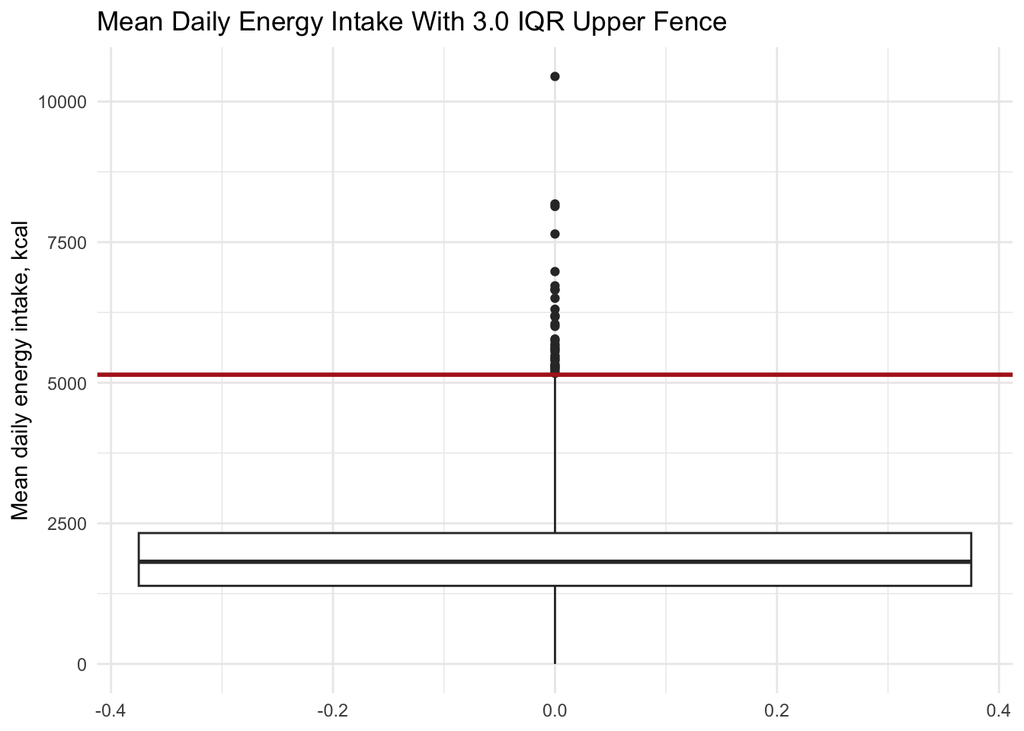

```r
ggplot(
  diet,
  aes(y = mean_daily_energy_kcal)
) +
  geom_boxplot(coef = 3) +
  geom_hline(
    yintercept = energy_cutoffs_3$upper_cutoff,
    color = "firebrick",
    linewidth = 1
  ) +
  labs(
    title = "Mean Daily Energy Intake With 3.0 IQR Upper Fence",
    x = NULL,
    y = "Mean daily energy intake, kcal"
  ) +
  theme_minimal()
```

| Plot component | Code in this chunk |
| --- | --- |
| Aesthetic mappings | `x`; `y` |
| Geoms / stats | `geom_boxplot()` |

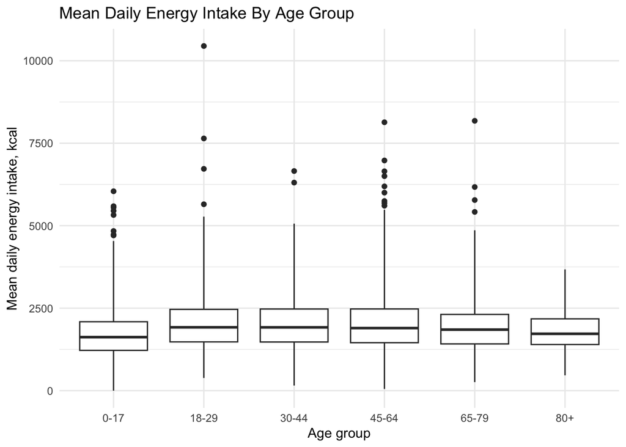

```r
ggplot(
  diet,
  aes(x = age_group, y = mean_daily_energy_kcal)
) +
  geom_boxplot(coef = 3) +
  labs(
    title = "Mean Daily Energy Intake By Age Group",
    x = "Age group",
    y = "Mean daily energy intake, kcal"
  ) +
  theme_minimal()
```

## Change The Outlier Points

We can also keep the default rule but change how the outlier points look.

| Plot component | Code in this chunk |
| --- | --- |
| `geom_boxplot()` properties | `outlier.shape` |

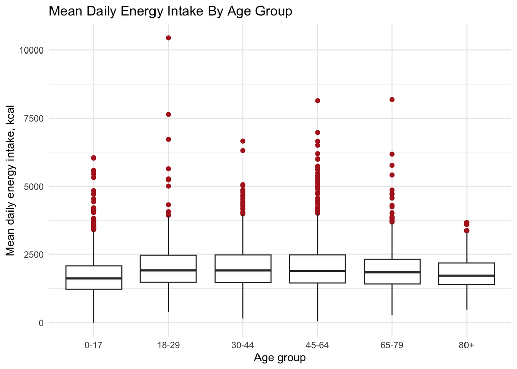

```r
ggplot(
  diet,
  aes(x = age_group, y = mean_daily_energy_kcal)
) +
  geom_boxplot(
    outlier.color = "firebrick",
    outlier.shape = 16,
    outlier.size = 2
  ) +
  labs(
    title = "Mean Daily Energy Intake By Age Group",
    x = "Age group",
    y = "Mean daily energy intake, kcal"
  ) +
  theme_minimal()
```

## Plot The Values

We can hide the outlier points drawn by the boxplot and then add all the individual values, using jitter to spread them out.

This helps us see how the full distribution looks instead of only seeing the points flagged by the boxplot rule.

In `ggplot2`, layer order matters. Layers added later are drawn on top of earlier layers.

First, draw the boxplot and put the jittered points on top.

| Plot component | Code in this chunk |
| --- | --- |
| Aesthetic mappings | `x`; `y`; `color` |
| Geoms / stats | `geom_boxplot()`; `geom_jitter()` |
| `geom_boxplot()` properties | `outlier.shape`; `fill`; `alpha` |
| `geom_jitter()` properties (layer 1) | `color`; `width`; `alpha`; `size` |
| `geom_jitter()` properties (layer 2) | `width`; `alpha`; `size` |
| Scales / coordinates / facets / labels | `scale_color_manual()`; `labs()`; `theme_minimal()` |

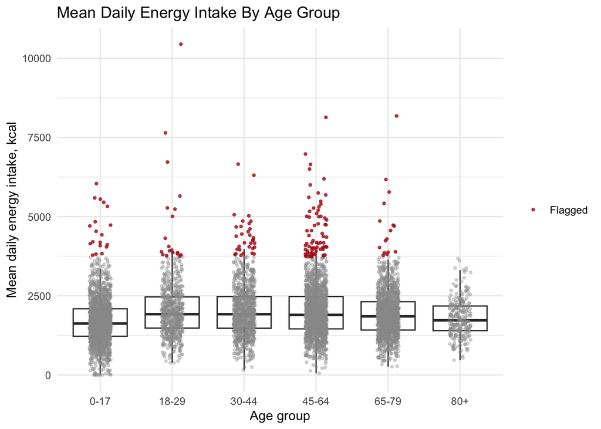

```r
ggplot(
  diet_flagged,
  aes(x = age_group, y = mean_daily_energy_kcal)
) +
  geom_boxplot(outlier.shape = NA, fill = "white", alpha = 0.8) +
  geom_jitter(
    data = diet_not_flagged,
    color = "gray60",
    width = 0.15,
    alpha = 0.35,
    size = 0.8
  ) +
  geom_jitter(
    data = diet_high_flagged,
    aes(color = "Flagged"),
    width = 0.15,
    alpha = 0.8,
    size = 0.8
  ) +
  scale_color_manual(
    values = c("Flagged" = "firebrick"),
    name = NULL
  ) +
  labs(
    title = "Mean Daily Energy Intake By Age Group",
    x = "Age group",
    y = "Mean daily energy intake, kcal"
  ) +
  theme_minimal()
```

Now reverse the order: draw the jittered points first and put the boxplot on top.

| Plot component | Code in this chunk |
| --- | --- |
| Geoms / stats | `geom_jitter()`; `geom_boxplot()` |

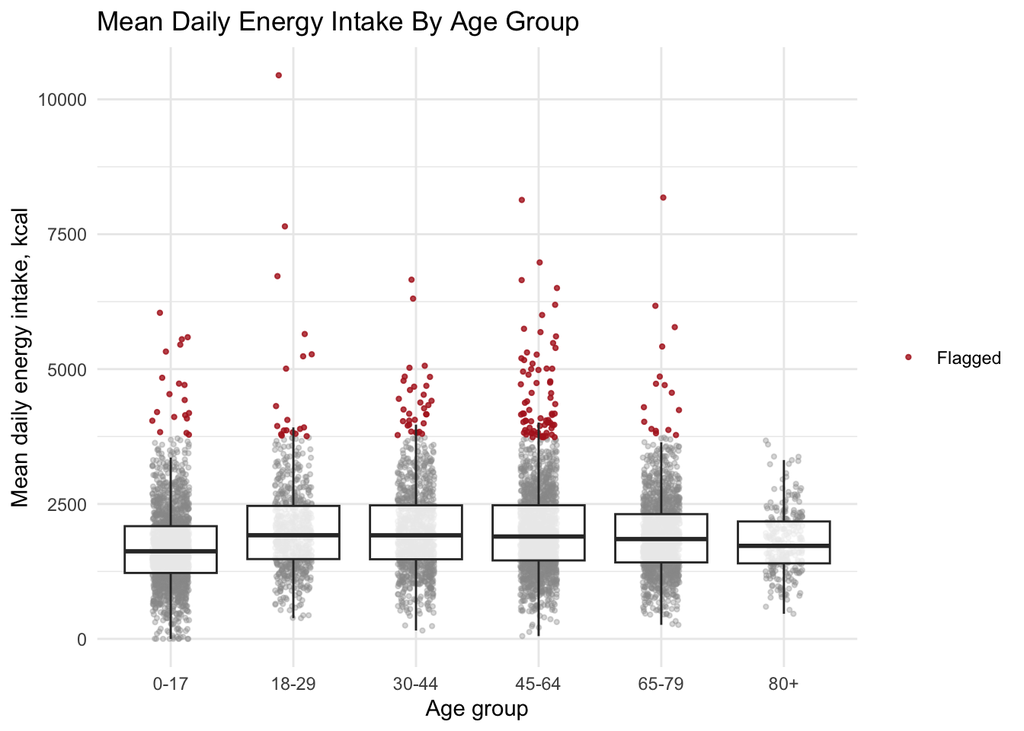

```r
ggplot(
  diet_flagged,
  aes(x = age_group, y = mean_daily_energy_kcal)
) +
  geom_jitter(
    data = diet_not_flagged,
    color = "gray60",
    width = 0.15,
    alpha = 0.35,
    size = 0.8
  ) +
  geom_jitter(
    data = diet_high_flagged,
    aes(color = "Flagged"),
    width = 0.15,
    alpha = 0.8,
    size = 0.8
  ) +
  geom_boxplot(outlier.shape = NA, fill = "white", alpha = 0.8) +
  scale_color_manual(
    values = c("Flagged" = "firebrick"),
    name = NULL
  ) +
  labs(
    title = "Mean Daily Energy Intake By Age Group",
    x = "Age group",
    y = "Mean daily energy intake, kcal"
  ) +
  theme_minimal()
```

The data are the same in both plots. The layer order changes which part of the display visually sits on top.

Adding points can help add useful context about the plot, such as how many points are in each category.

# Show The Flagged Rows In A Table

When appropriate, we can show collaborators the rows behind the flagged values.

Here we use the wider 3.0 IQR rule and arrange the table by the energy value.

| Data preparation step | Functions in this chunk |
| --- | --- |
| Keep or remove rows | `filter()` |
| Choose or rename columns | `select()` |
| Sort rows | `arrange()`; `desc()` |

```r
energy_3_iqr_flagged <- diet |>
  filter(mean_daily_energy_kcal > energy_cutoffs_3$upper_cutoff) |>
  arrange(desc(mean_daily_energy_kcal)) |>
  select(
    respondent_id,
    age_years,
    gender,
    age_group,
    dietary_days,
    mean_daily_energy_kcal
  )

DT::datatable(
  energy_3_iqr_flagged,
  rownames = FALSE,
  options = list(pageLength = 10)
)
```

| respondent_id | age_years | gender | age_group | dietary_days | mean_daily_energy_kcal |
| --- | --- | --- | --- | --- | --- |
| 139174 | 27 | male | 18-29 | 1 | 10446 |
| 135541 | 68 | male | 65-79 | 1 | 8179 |
| 135173 | 58 | male | 45-64 | 2 | 8135 |
| 138180 | 18 | male | 18-29 | 1 | 7645 |
| 136473 | 60 | male | 45-64 | 2 | 6977 |
| 130904 | 28 | male | 18-29 | 1 | 6723 |
| 139856 | 35 | male | 30-44 | 1 | 6657 |
| 131077 | 47 | male | 45-64 | 2 | 6649.5 |
| 130801 | 56 | male | 45-64 | 2 | 6502.5 |
| 131498 | 41 | female | 30-44 | 2 | 6306.5 |

[output cut: 22 more lines]

Interactive tables can be useful for review, but use them carefully. Do not share sensitive row-level data unless it is appropriate for the setting and audience.

# Violin Plots

Violin plots use smoothing to show the shape of a distribution within each group. They let you see the distribution of a measure through the density, and get a better sense of the range/outliers through the boxplot.

| Plot component | Code in this chunk |
| --- | --- |
| Aesthetic mappings | `x`; `y` |
| Geoms / stats | `geom_violin()` |
| `geom_violin()` properties | `fill`; `color` |
| Scales / coordinates / facets / labels | `labs()`; `theme_minimal()` |

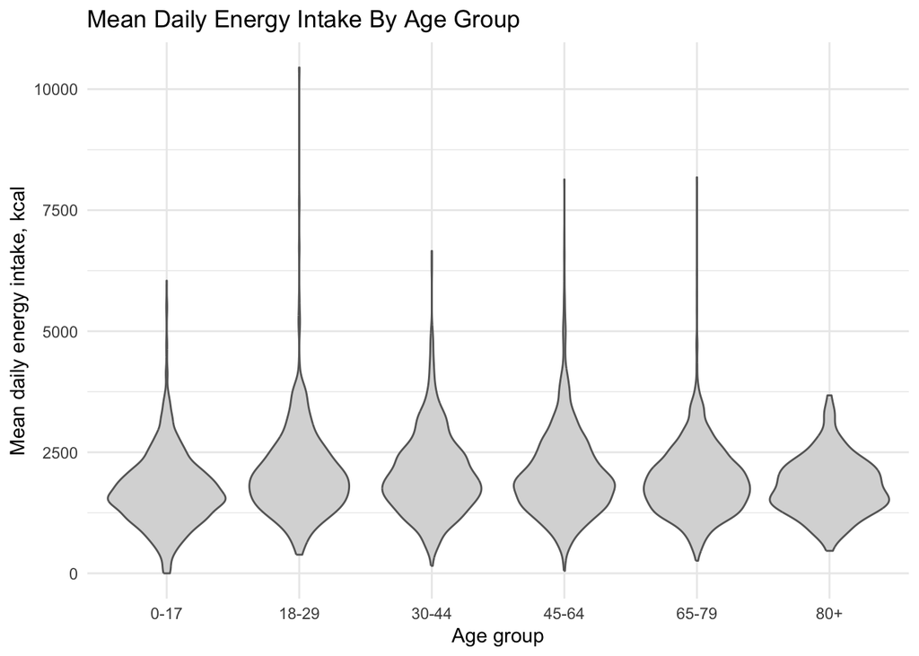

```r
ggplot(
  diet,
  aes(x = age_group, y = mean_daily_energy_kcal)
) +
  geom_violin(fill = "gray85", color = "gray40") +
  labs(
    title = "Mean Daily Energy Intake By Age Group",
    x = "Age group",
    y = "Mean daily energy intake, kcal"
  ) +
  theme_minimal()
```

The violin plot makes the width of each distribution visible, but it hides the median and the middle 50% of values unless we add another layer.

| Plot component | Code in this chunk |
| --- | --- |
| Geoms / stats | `geom_violin()`; `geom_boxplot()` |
| `geom_boxplot()` properties | `width`; `outlier.shape`; `fill`; `color`; `linewidth` |

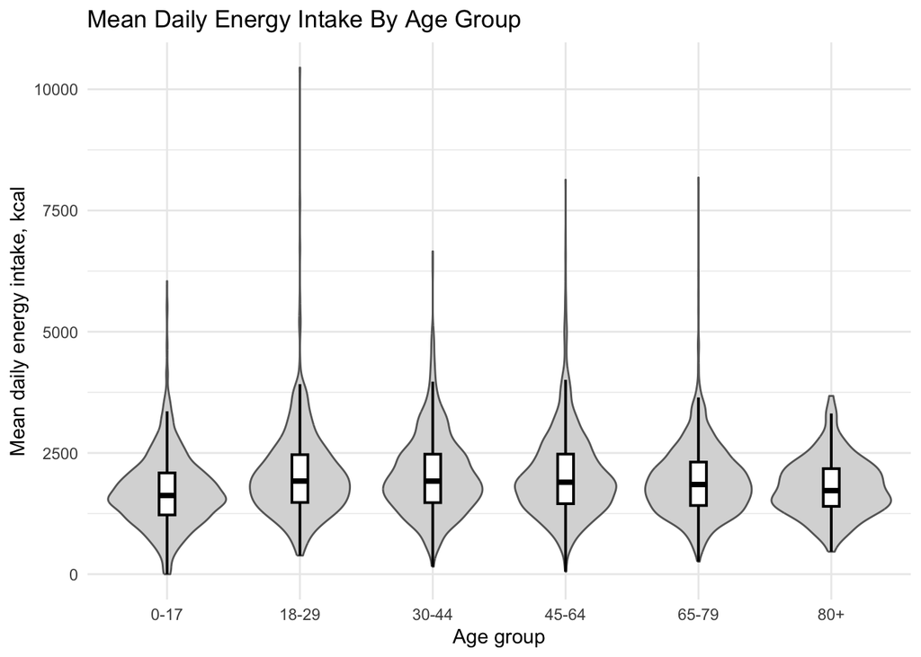

```r
ggplot(
  diet,
  aes(x = age_group, y = mean_daily_energy_kcal)
) +
  geom_violin(fill = "gray85", color = "gray40") +
  geom_boxplot(
    width = 0.12,
    outlier.shape = NA,
    fill = "white",
    color = "black",
    linewidth = 0.7
  ) +
  labs(
    title = "Mean Daily Energy Intake By Age Group",
    x = "Age group",
    y = "Mean daily energy intake, kcal"
  ) +
  theme_minimal()
```

The boxplot layer adds the median and middle spread back onto the smoothed shape.

| Plot component | Code in this chunk |
| --- | --- |
| Aesthetic mappings | `x`; `y`; `color` |
| Geoms / stats | `geom_violin()`; `geom_jitter()` |
| `geom_jitter()` properties (layer 1) | `color`; `width`; `alpha`; `size` |
| `geom_jitter()` properties (layer 2) | `width`; `alpha`; `size` |
| Scales / coordinates / facets / labels | `scale_color_manual()`; `labs()`; `theme_minimal()` |

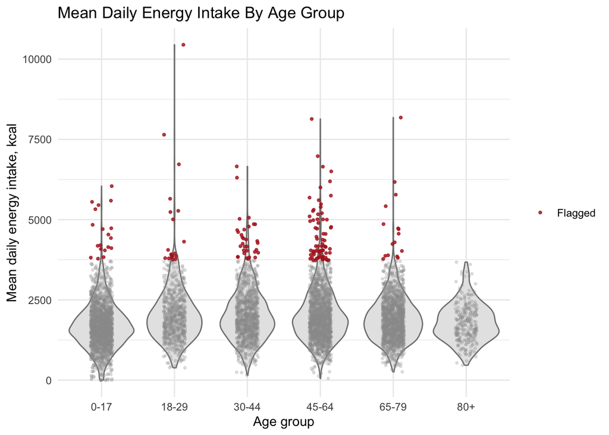

```r
ggplot(
  diet_flagged,
  aes(x = age_group, y = mean_daily_energy_kcal)
) +
  geom_violin(fill = "gray90", color = "gray50") +
  geom_jitter(
    data = diet_not_flagged,
    color = "gray60",
    width = 0.15,
    alpha = 0.25,
    size = 0.7
  ) +
  geom_jitter(
    data = diet_high_flagged,
    aes(color = "Flagged"),
    width = 0.15,
    alpha = 0.8,
    size = 0.8
  ) +
  scale_color_manual(
    values = c("Flagged" = "firebrick"),
    name = NULL
  ) +
  labs(
    title = "Mean Daily Energy Intake By Age Group",
    x = "Age group",
    y = "Mean daily energy intake, kcal"
  ) +
  theme_minimal()
```

# Takeaways

- Unusual values can be errors, true rare values, or signs that the variable needs context.
- The default boxplot rule of 1.5 IQR is a screening tool, not a final judgment. Use your scientific judgment to inform what you would consider an outlier.
- Visualization helps show whether unusual values are isolated or part of a tail.
- Try out different methods to see what is the most useful for you.